# Instacart Visualizations

## This scipt includes the following points:

### 1. Key Question 1 Visualizations (bar graph, histogram)

### 2. Key Question 2 Visualizations (line charts)

### 3. Key Question 3 Visualizations (bar graph)

### 4. Key Question 4 Visualizations (bar graph)

### 5. Key Question 5 Visualizations (bar graphs)

### 6. Key Question 6 Visualizations: Customer Profiles, Income, Age, Dependants, Departments, Other (bar graphs, histograms, line charts, stacked bar graphs, scatterplots)

### 7. Key Question 7 Visualizations: Region, Regional Expenditures, Regional Orders, Regional Departments (bar graphs)

```python
#Import Libraries
import pandas as pd
import numpy as np
import os
import matplotlib.pyplot as plt
import seaborn as sns
import scipy
```

```python
#Import data
path = r'D:\Users\Marlo\OneDrive\OneDrive - South Washington County Schools\Home\job support\Coursework\Achievement 4\Instacart Basket Analysis'
```

```python
ords_prods_cust_dept = pd.read_pickle(os.path.join(path, '02 Data', 'Prepared Data', 'ords_prods_cust_dept.pkl'))
```

### 1. Key Question 1 Visualizations

#### Busiest Days of the Week

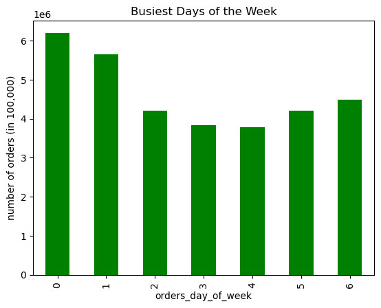

```python
#create bar graph: Busiest Days of the Week
bar_busiest_day = ords_prods_cust_dept['orders_day_of_week'].value_counts(). sort_index().plot.bar(color = ['green'])
plt.title('Busiest Days of the Week')
plt.ylabel('number of orders (in 100,000)')
```

Saturday and Sunday are the busiest days of the week.

```python
#Export bar_busiest_day
bar_busiest_day.figure.savefig(os.path.join(path, '04 Analysis', 'Visualizations', 'bar_busiest_day'))
```

#### Busiest Hour of Day

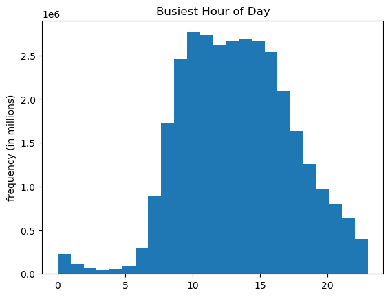

```python
#Create historgram about order hour of day
hist_hour = ords_prods_cust_dept['order_hour_of_day'].plot.hist(bins = 24)
plt.title('Busiest Hour of Day')
plt.ylabel('frequency (in millions)')
```

10:00AM-3:00PM are the busiest hours of the day.

```python
#Export hist_hour
hist_hour.figure.savefig(os.path.join(path, '04 Analysis', 'Visualizations', 'hist_hour'))
```

### 2. Key Question 2 Visualizations

#### Create Sample

```python
#create a seed
np.random.seed(4)
```

```python
#Create a list holding True/False values to the test np.random.rant() <=0.7
dev = np.random.rand(len(ords_prods_cust_dept)) <= 0.7
```

```python
#Store 70% of the sample in the dataframe big_1
big_1 = ords_prods_cust_dept[dev]
```

```python
#Store 30% of the sample in the dataframe small
small_1 = ords_prods_cust_dept[~dev]
```

```python
#Check number of rows in ords_prods_cust_dept
len(ords_prods_cust_dept)
```

```
32404859
```

```python
#check number of rows in big_1 + small_1
len(big_1)+len(small_1)
```

```
32404859
```

#### Spending Per Day

```python
#Make data set that only includes the columns order_hour_of_day and prices
merge_sample = small_1[['order_hour_of_day', 'orders_day_of_week','prices']]
```

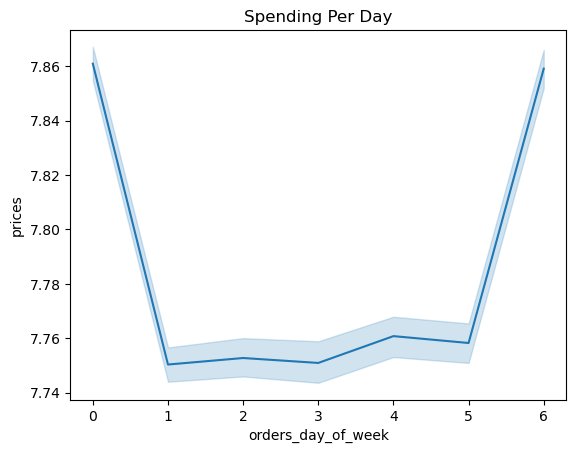

```python
#Create line graph showing prices depending on day of week
line_2 = sns.lineplot(data = merge_sample, x = 'orders_day_of_week', y = 'prices')
plt.title('Spending Per Day')
```

Friday and Saturday are the days that the most money is spent.

```python
#Export line_2
line_2.figure.savefig(os.path.join(path, '04 Analysis', 'Visualizations', 'line_2'))
```

#### Spending Per Hour

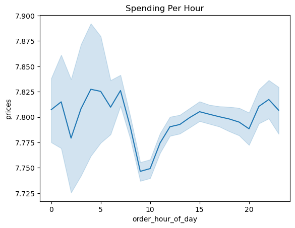

```python
#Create line graph showing prices depending on order hour of day
line_1 = sns.lineplot(data = merge_sample, x = 'order_hour_of_day', y = 'prices')
plt.title('Spending Per Hour')
```

The most money is spent between 4:00AM-7:00AM.

```python
#Export line_1
line_1.figure.savefig(os.path.join(path, '04 Analysis', 'Visualizations', 'line_1'))
```

### 3. Key Question 3 Visualizations

#### Frequency of Product Price Ranges

```python
#define function price_range
ords_prods_cust_dept.loc[ords_prods_cust_dept['prices']>15, 'price_range']= 'High-Range Product'
```

```python
ords_prods_cust_dept.loc[(ords_prods_cust_dept['prices'] <= 15) & (ords_prods_cust_dept['prices'] > 5), 'price_range'] = 'Mid-range product'
```

```python
ords_prods_cust_dept.loc[ords_prods_cust_dept['prices'] <= 5, 'price_range'] = 'Low-range product'
```

```python
#check outputs
ords_prods_cust_dept['price_range'].value_counts(dropna = False)
```

```
price_range
Mid-range product     21861558
Low-range product     10130750
High-Range Product      412551
Name: count, dtype: int64
```

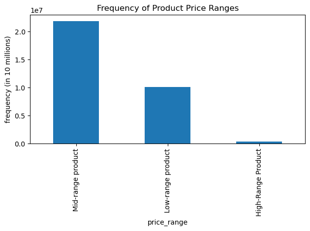

```python
#create bar chart showing price ranges
bar_price_ranges = ords_prods_cust_dept['price_range'].value_counts().plot.bar()
plt.title('Frequency of Product Price Ranges')
plt.ylabel('frequency (in 10 millions)')
plt.tight_layout()
```

Products have been grouped by:

"high-range" product (more than 15)

"mid-range" product (more than 5 and less than or equal to 15)

"low-range" product (less than or equal to 5)

```python
#Export bar_price_ranges
bar_price_ranges.figure.savefig(os.path.join(path, '04 Analysis', 'Visualizations', 'bar_price_ranges'))
```

### 4. Key Question 4 Visualizations

#### Frequency of Orders by Department

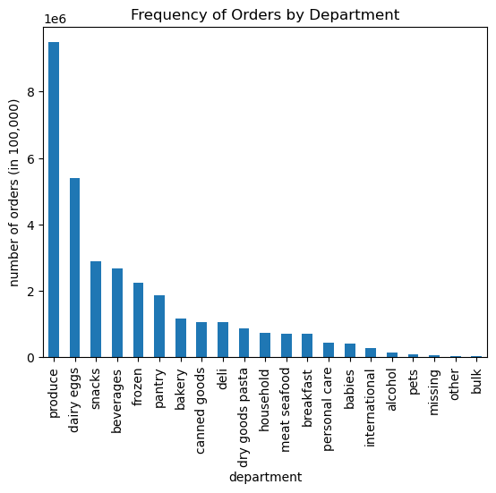

```python
#create bar graph showing frequency of orders in each department
bar_dept_names = ords_prods_cust_dept['department'].value_counts().plot.bar()
plt.title('Frequency of Orders by Department')
plt.ylabel('number of orders (in 100,000)')
```

Produce is the most frequently ordered type of item. Dairy & eggs is are the second most frequently ordered type of item.

```python
#Export Bar Graph
bar_dept_names.figure.savefig(os.path.join(path, '04 Analysis', 'Visualizations', 'bar_dept_names.png'))
```

### 5. Key Question 5 Visualizations

#### Frequency of Customer Loyalty

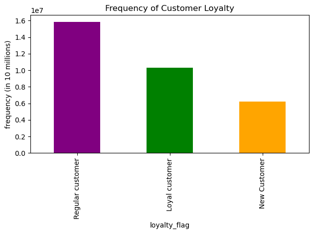

```python
#create bar chart showing customer loyalty
bar_loyalty = ords_prods_cust_dept['loyalty_flag'].value_counts().plot.bar(color=['purple', 'green', 'orange'])
plt.title('Frequency of Customer Loyalty')
plt.ylabel('frequency (in 10 millions)')
plt.tight_layout()
```

Most customers are considered regular customers. There are the least amount of new customers.

#### Expenditures Vs. Loyalty

```python
#aggregating 'order_id' and 'prices' from sample
loyalty = ords_prods_cust_dept.groupby(['department', 'loyalty_flag','region'], as_index=False).agg({'order_id': 'count', 'prices': 'sum'})
loyalty.head(3)
```

|  | department | loyalty_flag | region | order_id | prices |
| --- | --- | --- | --- | --- | --- |
| 0 | alcohol | Loyal customer | Midwest | 9176 | 75026.5 |
| 1 | alcohol | Loyal customer | Northeast | 6560 | 50704.7 |
| 2 | alcohol | Loyal customer | South | 13264 | 108746.8 |

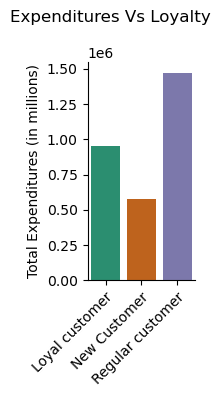

```python
### FacetGrid for loyalty_flag and Revenue
g2 = sns.FacetGrid(loyalty, height=4, aspect=.5,)
g2.map(sns.barplot, "loyalty_flag", "prices", palette='Dark2',ci=None)

g2.set_xticklabels(rotation=45,rotation_mode='anchor', ha='right')
g2.set_axis_labels("", "Total Expenditures (in millions)")
g2.fig.suptitle("Expenditures Vs Loyalty")
g2.figure.subplots_adjust(top=.8)
plt.tight_layout()
```

### 6. Key Question 6 Visualizations: Customer Profiles, Income, Age, Dependants, Departments, Other

### Customer Profiles

```python
#Group by customer_profile
customer_profile=ords_prods_cust_dept.groupby(['customer_profile','customer_profile']).size().unstack()
```

```python
#Sort
customer_profile = customer_profile.loc[customer_profile.sum(axis=1).sort_values(ascending = True).index]
```

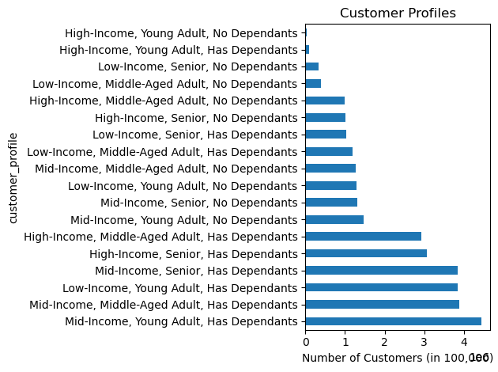

```python
#Create bar graph showing frequency of customer profiles
bar_customer_profile = ords_prods_cust_dept['customer_profile'].value_counts().plot.barh()
plt.title('Customer Profiles')
plt.xlabel('Number of Customers (in 100,000)')
plt.tight_layout()
```

Customer Profiles:

Mid-Income, Young Adults with Dependants are the largest group among customers.

The largest customer profiles all have dependents.

Mid-Income makes up 3/5 of the top customer profiles.

### Income

#### Customer Frequency Across Income

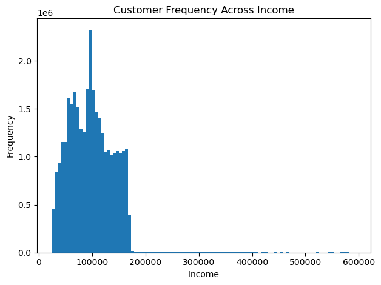

```python
#create histogram showing income of customers
hist_income = ords_prods_cust_dept['income'].plot.hist(bins=100)
plt.title('Customer Frequency Across Income')
plt.xlabel('Income')
plt.tight_layout()
```

The incomes of customers is skewed with the majority of customers making under 200k.

```python
#Export hist_income
hist_income.figure.savefig(os.path.join(path, '04 Analysis', 'Visualizations', 'hist_income'))
```

#### Customer Frequency Across Income Groups

```python
#Create income_group, low-income <= $67,004
ords_prods_cust_dept.loc[ords_prods_cust_dept['income'] <= 67004, "income_group"] = "Low-Income"
```

```python
#Create income_group flag, mid-income > $67,004, <= $127,912
ords_prods_cust_dept.loc[(ords_prods_cust_dept['income'] > 67004) & (ords_prods_cust_dept['income'] <=127912), "income_group"] = "Mid-Income"
```

```python
#Create income_group, high-income > $127,912
ords_prods_cust_dept.loc[ords_prods_cust_dept['income'] >127912, "income_group"] = "High-Income"
```

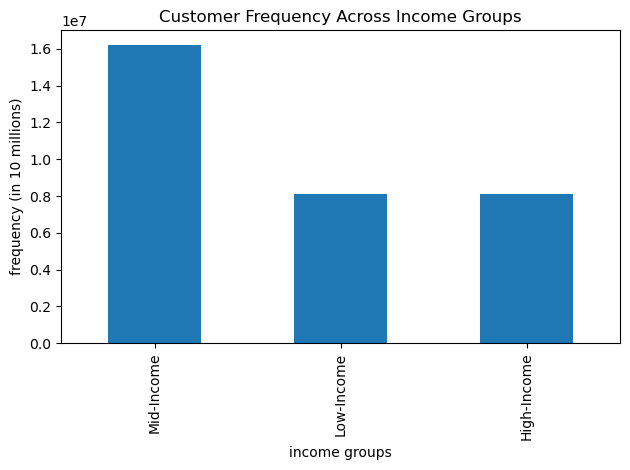

```python
#create bar graph showing income groups
bar_income = ords_prods_cust_dept['income_group'].value_counts().plot.bar()
plt.title('Customer Frequency Across Income Groups')
plt.ylabel('frequency (in 10 millions)')
plt.xlabel('income groups')
plt.tight_layout()
```

Most cuomsters are mid-income (67k-127k).

#### Weekly Orders by Income Group

```python
# user_profile of subset of 30% sample df_opd_small only containing necessary columns for analysis
income_group_sample = small_1[['income','region','income_group','orders_day_of_week', 'order_hour_of_day','department','prices','order_id', 'max_order']]
income_group_sample.shape
```

```
(9721098, 9)
```

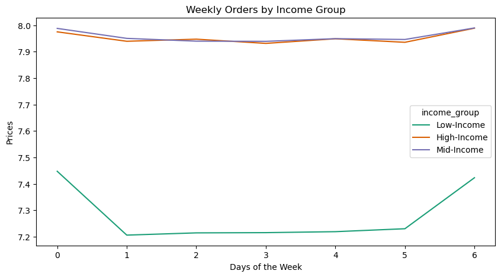

```python
#linechart for DOW and income
plt.figure(figsize=(10, 5))

sns.lineplot(data = income_group_sample,
             x='orders_day_of_week',
             y = 'prices',
             hue='income_group',
             palette = 'Dark2',
             errorbar=None
            )

plt.title("Weekly Orders by Income Group")
plt.xlabel("Days of the Week")
plt.ylabel("Prices")
plt.savefig('income_group_dow.png')
plt.show()
```

Low-Income customers consistently spend less on items compared to high-income and mid-income customers. Mid-income and high-income customers spend the same amount on items.

Low-income customers are more likely to spend more on Friday and Saturday than the rest of the week. Mid-income and high-income customers spend the same amount regardless of day of week.

#### Daily Orders by Income

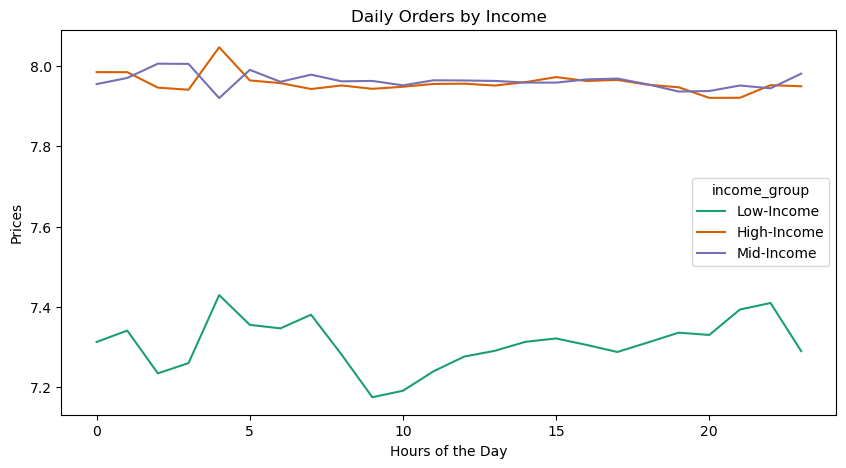

```python
#linechart for DOW and income
plt.figure(figsize=(10, 5))

sns.lineplot(data = income_group_sample,
             x='order_hour_of_day',
             y = 'prices',
             hue='income_group',
             palette = 'Dark2',
             errorbar=None
            )

plt.title("Daily Orders by Income")
plt.xlabel("Hours of the Day")
plt.ylabel("Prices")
plt.savefig('income2_group_dow.png')
plt.show()
```

Low-Income customers consistently spend less on items compared to high-income and mid-income customers. Mid-income and high-income customers spend the same amount on items.

Regardless of time of day, low-income customers are spending significantly less than high-income and mid-income customers.

#### Daily Number of Orders by Income

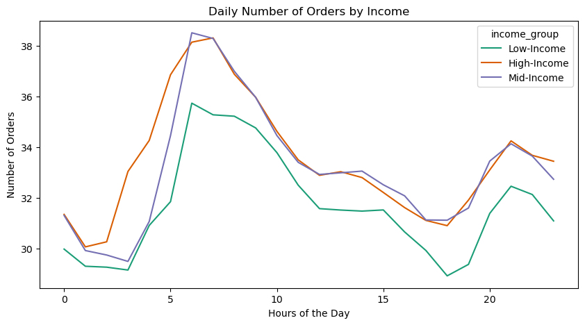

```python
#linechart for DOW and income
plt.figure(figsize=(10, 5))

sns.lineplot(data = income_group_sample,
             x='order_hour_of_day',
             y = 'max_order',
             hue='income_group',
             palette = 'Dark2',
             errorbar=None
            )

plt.title("Daily Number of Orders by Income")
plt.xlabel("Hours of the Day")
plt.ylabel("Number of Orders")
plt.savefig('income3_group_dow.png')
plt.show()
```

Across income groups, 6:00AM-8:00AM receive the most number of orders.

Across income groups, 12:00AM-3:00AM and 5:00PM-8:00PM receive the least amount of orders.

### Weekly Number of Orders by Income Group

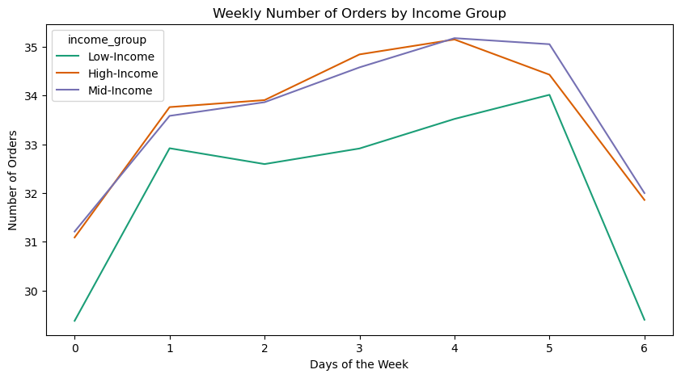

```python
#linechart for DOW and income
plt.figure(figsize=(10, 5))

sns.lineplot(data = income_group_sample,
             x='orders_day_of_week',
             y = 'max_order',
             hue='income_group',
             palette = 'Dark2',
             errorbar=None
            )

plt.title("Weekly Number of Orders by Income Group")
plt.xlabel("Days of the Week")
plt.ylabel("Number of Orders")
plt.savefig('income_group_dow.png')
plt.show()
```

Across income groups, Wednesday and Thursday receive the largest number of orders.

Across income groups, Friday and Saturday receive the least amount of orders.

### Age

#### Customer Frequency Across Ages

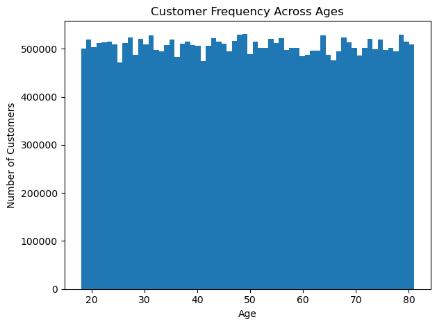

```python
#create histogram showing age of customers
hist_age = ords_prods_cust_dept['age'].plot.hist(bins=64)
plt.title('Customer Frequency Across Ages')
plt.ylabel('Number of Customers')
plt.xlabel('Age')
plt.tight_layout()
```

There is approximately the same number of people across ages 18-81.

```python
#Export hist_age
hist_age.figure.savefig(os.path.join(path, '04 Analysis', 'Visualizations', 'hist_age'))
```

#### Customer Frequency Across Age Groups

```python
#Create age_group flag, young adult <40
ords_prods_cust_dept.loc[ords_prods_cust_dept['age'] <40, "age_group"] = "Young Adult"
```

```python
#Create age_group flag, middle-age >=40, <=60
ords_prods_cust_dept.loc[(ords_prods_cust_dept['age'] >=40) & (ords_prods_cust_dept['age'] <=60), "age_group"] = "Middle-Aged Adult"
```

```python
#Create age_group flag, senior >60
ords_prods_cust_dept.loc[ords_prods_cust_dept['age'] >60, "age_group"] = "Senior"
```

```python
#check outputs
ords_prods_cust_dept['age_group'].value_counts(dropna = False)
```

```
age_group
Young Adult          11164192
Middle-Aged Adult    10657828
Senior               10582839
Name: count, dtype: int64
```

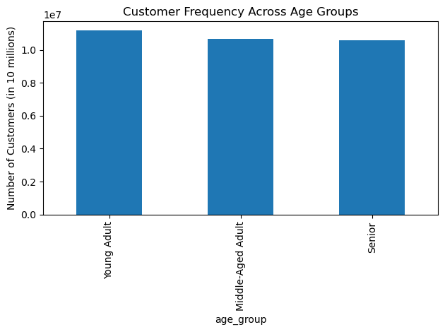

```python
#create bar graph showing age groups
bar_age = ords_prods_cust_dept['age_group'].value_counts().plot.bar()
plt.title("Customer Frequency Across Age Groups")
plt.ylabel("Number of Customers (in 10 millions)")
plt.tight_layout()
```

There is approximately the same number of people in each age group.

#### Weekly Orders by Age Group

```python
# user_profile of subset of 30% sample df_opd_small only containing necessary columns for analysis
age_group_sample = small_1[['age','region','age_group','orders_day_of_week', 'order_hour_of_day','department','prices','order_id', 'max_order']]
age_group_sample.shape
```

```
(9721098, 9)
```

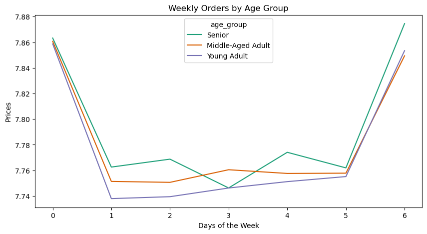

```python
#linechart for DOW and age
plt.figure(figsize=(10, 5))

sns.lineplot(data = age_group_sample,
             x='orders_day_of_week',
             y = 'prices',
             hue='age_group',
             palette = 'Dark2',
             errorbar=None
            )

plt.title("Weekly Orders by Age Group")
plt.xlabel("Days of the Week")
plt.ylabel("Prices")
plt.savefig('Age_group_dow.png')
plt.show()
```

Acrpss age groups, the price of orders is highest on Friday and Saturday.

#### Daily Orders by Age

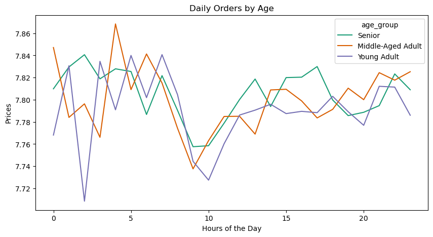

```python
#linechart for DOW and age
plt.figure(figsize=(10, 5))

sns.lineplot(data = age_group_sample,
             x='order_hour_of_day',
             y = 'prices',
             hue='age_group',
             palette = 'Dark2',
             errorbar=None
            )

plt.title("Daily Orders by Age")
plt.xlabel("Hours of the Day")
plt.ylabel("Prices")
plt.savefig('age2_group_dow.png')
plt.show()
```

#### Daily Number of Orders by Age

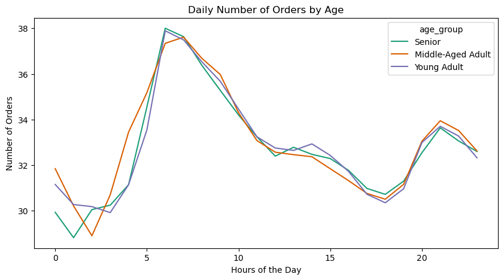

```python
#linechart for DOW and age
plt.figure(figsize=(10, 5))

sns.lineplot(data = age_group_sample,
             x='order_hour_of_day',
             y = 'max_order',
             hue='age_group',
             palette = 'Dark2',
             errorbar=None
            )

plt.title("Daily Number of Orders by Age")
plt.xlabel("Hours of the Day")
plt.ylabel("Number of Orders")
plt.savefig('age3_group_dow.png')
plt.show()
```

Similar to the income analysis, the least number of orders are placed between 12:00AM-3:00AM and 5:00PM-8:00PM.

#### Weekly Number of Orders by Age Group

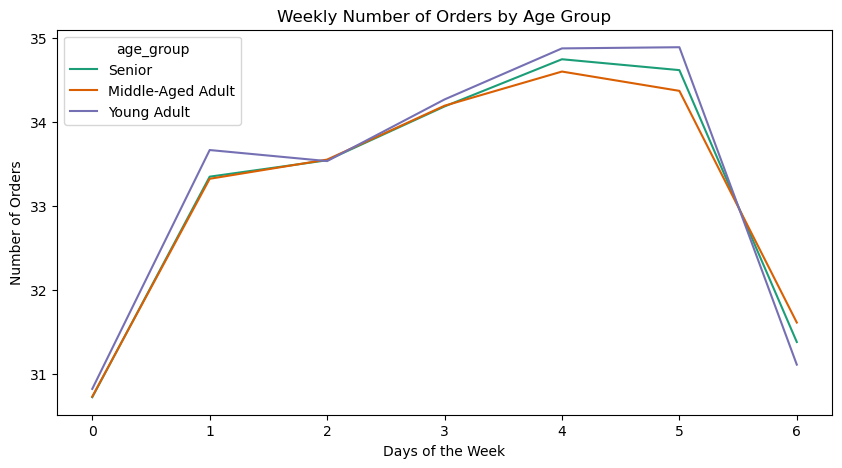

```python
#linechart for DOW and age
plt.figure(figsize=(10, 5))

sns.lineplot(data = age_group_sample,
             x='orders_day_of_week',
             y = 'max_order',
             hue='age_group',
             palette = 'Dark2',
             errorbar=None
            )

plt.title("Weekly Number of Orders by Age Group")
plt.xlabel("Days of the Week")
plt.ylabel("Number of Orders")
plt.savefig('Age_group_dow.png')
plt.show()
```

Similar to the income analysis, the least number of orders are made on Friday and Saturday across age groups.

### Dependants

#### Number of Dependants

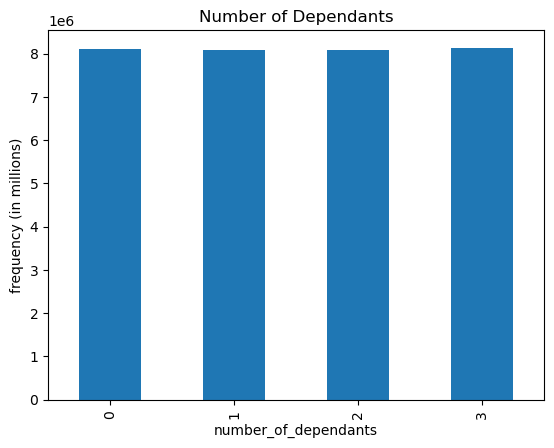

```python
bar_dependants = ords_prods_cust_dept['number_of_dependants'].value_counts().sort_index().plot.bar()
plt.title('Number of Dependants')
plt.ylabel('frequency (in millions)')
```

There is approximately the same number of customers who have 0, 1, 2, and 3 dependants.

```python
#Export bar_dependants
bar_dependants.figure.savefig(os.path.join(path, '04 Analysis', 'Visualizations', 'bar_dependants'))
```

#### Customers with Dependants

```python
#Create dependants groups, no dependants
ords_prods_cust_dept.loc[ords_prods_cust_dept['number_of_dependants']== 0, "dependants_flag"] = 'No Dependants'
```

```python
#Create dependants groups, has dependants
ords_prods_cust_dept.loc[ords_prods_cust_dept['number_of_dependants'] > 0, "dependants_flag"] = 'Has Dependants'
```

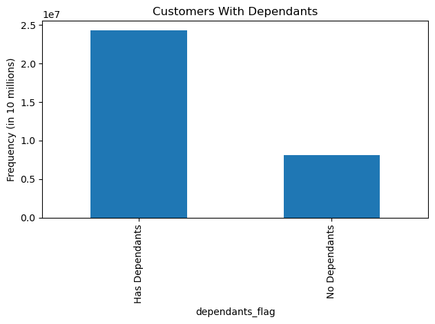

```python
#create bar graph showing customers with dependants
bar_dependants2 = ords_prods_cust_dept['dependants_flag'].value_counts().plot.bar()
plt.title('Customers With Dependants')
plt.ylabel('Frequency (in 10 millions)')
plt.tight_layout()
```

Approximately 75% of customers have dependants.

```python
#Export bar_dependants2
bar_dependants2.figure.savefig(os.path.join(path, '04 Analysis', 'Visualizations', 'bar_dependants2'))
```

#### Weekly Orders by Number of Dependants

```python
# user_profile of subset of 30% sample df_opd_small only containing necessary columns for analysis
dependants_group_sample = small_1[['number_of_dependants','region','dependants_flag','orders_day_of_week', 'order_hour_of_day','department','prices','order_id', 'max_order']]
dependants_group_sample.shape
```

```
(9721098, 9)
```

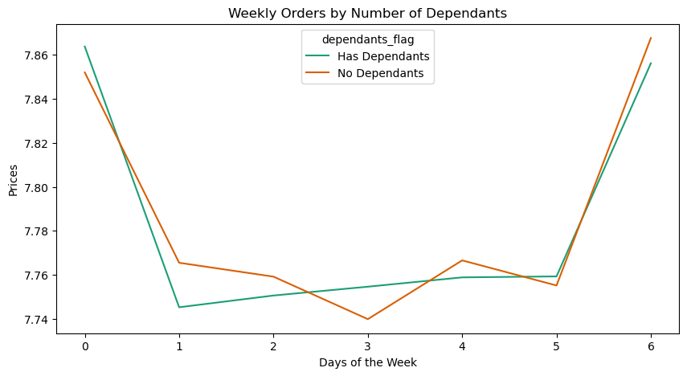

```python
#linechart for DOW and dependants
plt.figure(figsize=(10, 5))

sns.lineplot(data = dependants_group_sample,
             x='orders_day_of_week',
             y = 'prices',
             hue='dependants_flag',
             palette = 'Dark2',
             errorbar=None
            )

plt.title("Weekly Orders by Number of Dependants")
plt.xlabel("Days of the Week")
plt.ylabel("Prices")
plt.savefig('dependants_group_dow.png')
plt.show()
```

There is no significant difference in price of orders when looking if a customer has dependants or not.

#### Daily Orders by Number of Dependants

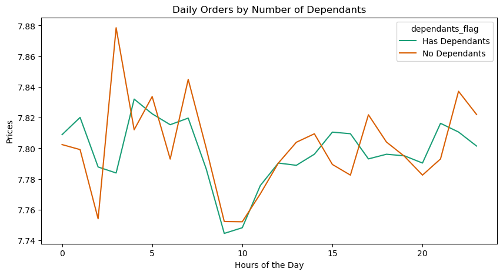

```python
#linechart for DOW and dependants
plt.figure(figsize=(10, 5))

sns.lineplot(data = dependants_group_sample,
             x='order_hour_of_day',
             y = 'prices',
             hue='dependants_flag',
             palette = 'Dark2',
             errorbar=None
            )

plt.title("Daily Orders by Number of Dependants")
plt.xlabel("Hours of the Day")
plt.ylabel("Prices")
plt.savefig('dependants2_group_dow.png')
plt.show()
```

People with no dependants spend less than those with dependants at 2:00AM and spend more at 3:00AM.

#### Daily Number of Orders by Number of Dependants

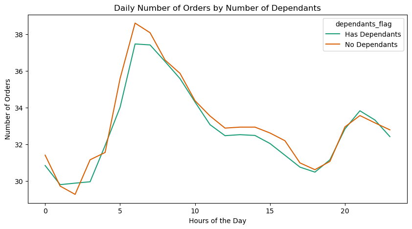

```python
#linechart for DOW and dependants
plt.figure(figsize=(10, 5))

sns.lineplot(data = dependants_group_sample,
             x='order_hour_of_day',
             y = 'max_order',
             hue='dependants_flag',
             palette = 'Dark2',
             errorbar=None
            )

plt.title("Daily Number of Orders by Number of Dependants")
plt.xlabel("Hours of the Day")
plt.ylabel("Number of Orders")
plt.savefig('dependants3_group_dow.png')
plt.show()
```

There is no significant difference in number of orders when looking if a customer has dependants or not.

#### Weekly Number of Orders by Number of Dependants

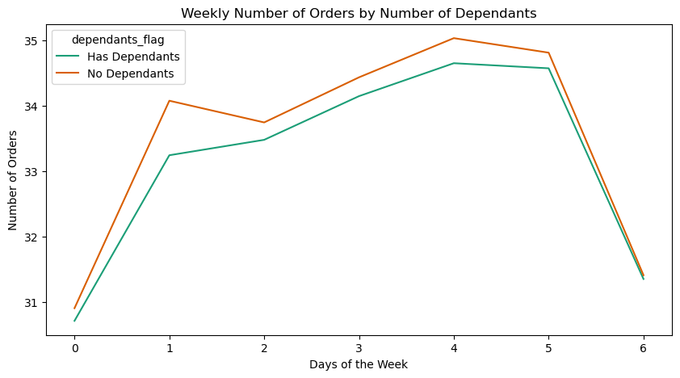

```python
#linechart for DOW and dependants
plt.figure(figsize=(10, 5))

sns.lineplot(data = dependants_group_sample,
             x='orders_day_of_week',
             y = 'max_order',
             hue='dependants_flag',
             palette = 'Dark2',
             errorbar=None
            )

plt.title("Weekly Number of Orders by Number of Dependants")
plt.xlabel("Days of the Week")
plt.ylabel("Number of Orders")
plt.savefig('dependants4_group_dow.png')
plt.show()
```

There is no significant difference in number of orders when looking if a customer has dependants or not.

### Departments

#### Customer Profiles by Department

```python
#Group by customer profile and department
profile_department=ords_prods_cust_dept.groupby(['customer_profile','department']).size().unstack()
```

```python
#Sort
profile_department = profile_department.loc[profile_department.sum(axis=1).sort_values(ascending = True).index]
```

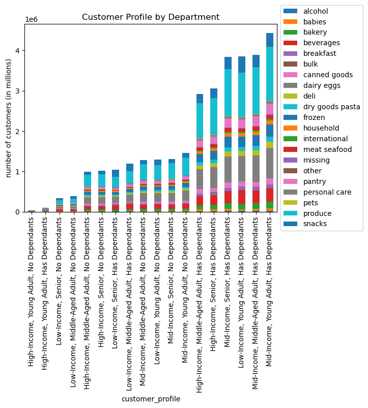

```python
#create bar graph
bar_profile_department = profile_department.plot.bar(stacked = True, title = 'Customer Profile by Department', ylabel = 'number of customers (in millions)')
plt.legend(loc='center left', bbox_to_anchor=(1, 0.5))
```

Across all customer profiles, produce is the most popular department, followed by dairy & eggs.

There is no significant difference between income, age, and dependants groups.

```python
#Export bar_profile_department
bar_profile_department.figure.savefig(os.path.join(path, '04 Analysis', 'Visualizations', 'bar_profile_department'))
```

#### Department by Income

```python
#Group by income and department
trial2=ords_prods_cust_dept.groupby(['department','income_group']).size().unstack()
```

```python
#Sort
trial2 = trial2.loc[trial2.sum(axis=1).sort_values(ascending = True).index]
```

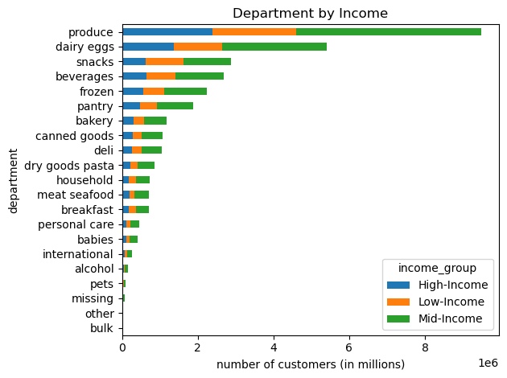

```python
#create bar graph
bar_trial2 = trial2.plot.barh(stacked = True, title = 'Department by Income', xlabel = 'number of customers (in millions)')
plt.tight_layout()
```

Produce is the most popular department, followed by dairy & eggs.

There is no significant difference between income groups.

```python
#Export bar_trial2
bar_trial2.figure.savefig(os.path.join(path, '04 Analysis', 'Visualizations', 'bar_trial2'))
```

#### Department by Age

```python
#Group by age and department
trial3=ords_prods_cust_dept.groupby(['department','age_group']).size().unstack()
```

```python
#Sort
trial3 = trial3.loc[trial3.sum(axis=1).sort_values(ascending = True).index]
```

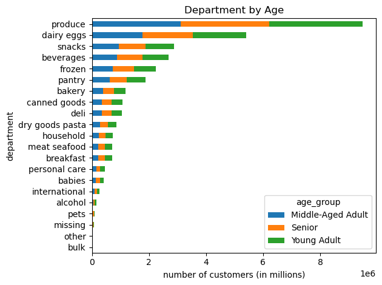

```python
#create bar graph
bar_trial3 = trial3.plot.barh(stacked = True, title = 'Department by Age', xlabel = 'number of customers (in millions)')
plt.tight_layout()
```

Produce is the most popular department, followed by dairy & eggs.

There is no significant difference between age groups.

```python
#Export bar_trial3
bar_trial3.figure.savefig(os.path.join(path, '04 Analysis', 'Visualizations', 'bar_trial3'))
```